# Homework 1: Can chimpanzees solve problems?

Introduction to Thinking Statistically

In 1978, researchers Premack and Woodru published a study in *Science magazine*, reporting an experiment where an adult chimpanzee named Sarah, was shown videotapes of eight different scenarios of a human being faced with a problem. After each videotape showing, she was presented with two photographs, one of which depicted a possible solution to the problem.

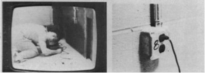

For example, in one videotape she was shown that a human was unable to hear any sound coming out of a boombox. Of the two photographs shown to her, one was a picture of an electric plug and a power outlet. The other was a picture of man climbing a ladder.

Out of the 8 problems, Sarah picked the photograph with the correct solution 7 times.

1. Identify the following in the context of this example:
- Population of interest:
- Sample:
- Variable of interest:
- Data type:
2. Complete a possible data set in which the information could be stored. Label the columns.
3. Sketch a stacked bar chart to display the distribution of Sarah’s answers (our observed data). Think about the two possible outcomes.
4. What are some possible explanations for Sarah getting 7 out of 8 correct?
5. In a well-designed study, the only two possible explanations for the observed results of a study are:

A:

B:

6. Which explanation do you think is a better (more plausible, that is, more reasonable) explanation for Sarah’s observed results?

Choose one: (A or B)

How would you convince a skeptic that the other explanation (_____) is not a reasonable explanation for Sarah’s observed results?

7. Describe how you can use an everyday item to convince a skeptic that random chance is not a reasonable explanation of Sarah’s results.
8. Now carry out two trials of the simulation process by doing the following:
- **Trial 1:** Flip a coin _____ times, and record the number of heads = _____
- **Trial 2:** Repeat. Flip a coin _____ times, and record the number of heads = _____
9. Sketch out stacked bar plots of your two simulation trials. How do they compare to the stacked barplot of Sarah’s observed answers you sketched in Question 3?
10. Now translate your two simulation trials into a dotplot. Label the axes.
11. What was (or do you expect to be) the most common outcome(s) for “number of heads” in 8 coin tosses? Why does that make sense?
12. The probability of heads when we toss a coin is 0.5 or 50%. So, on 8 coin tosses, we expect to get 4 heads. Then, why didn’t everyone get 4 heads on 8 coin tosses. Why the variability?
15. Why do we need to repeat the set of 8 coin tosses? Why not just look at one set of 8 coin tosses?
16. Carry out the simulation via http://www.rossmanchance.com/applets/2021/oneprop/OneProp.htm. Note that you should consider the following questions when designing your simulation study:
- What are the two possible outcomes on each of the trials?
- What is the probability that the Sarah selects the correct solution under the assumption that Sarah cannot solve problems? Change your `Probability of heads` accordingly.
- How many trials were conducted in this study? Keep this value in mind when setting the `Number of tosses` value.

Carry out the simulation study 100 times overall, keeping track of the number of trials in which the correct solution was selected in each of the simulated experiments.

In the space below, paste/insert/sketch the screenshot of the dotplot generated in Question 16. Be sure to that the axes labels - “Number of heads” - is visible, and the center of the dotplot, as well as the range of the outcomes on the axis are visible.

17. What does each dot on this plot represent?
18. On the dotplot in Question 10, indicate where Sarah’s actual/observed result is. Based on the dotplot that shows 100 possible results that could-happen if Sarah were just guessing/randomly choosing a photograph, does a result such as 7 correct answers out of 8 appear very surprising, somewhat surprising or not surprising by random chance alone?

**Circle one:** Very surprising Somewhat surprising Not surprising

How did you decide? Choose one.

1. Because the overall shape of the dotplot is symmetric
2. Because the dotplot is centered at about 4
3. Because 7 seems far out in the tail, and appears rare and unlikely to happen to by chance alone
19. Based on your findings so far, which of the following statements is accurate?
1. This *proves* that Sarah does better than just guess.
2. This provides *strong evidence* that Sarah does better than just guess.

Explain.

20. Suppose that Sarah had picked 5 answers correctly out of 8. Based on the above dotplot from the applet simulation, if Sarah tends to just randomly choose a photograph, would a result such as 5 correct out of 8 be very surprising, somewhat surprising, or not at all surprising? Explain how you are deciding.

**Canvas Quiz**

Make sure to complete the Homework Quiz on Canvas.